# Practical Machine Learning - Prediction Assignment Writeup

gjamnitz

Sunday, May 24, 2015

### Introduction

Using devices such as Jawbone Up, Nike FuelBand, and Fitbit it is now possible to collect a large amount of data about personal activity relatively inexpensively. These type of devices are part of the quantified self movement - a group of enthusiasts who take measurements about themselves regularly to improve their health, to find patterns in their behavior, or because they are tech geeks. One thing that people regularly do is quantify how much of a particular activity they do, but they rarely quantify how well they do it. In this project I used data from accelerometers on the belt, forearm, arm, and dumbell of 6 participants (who were asked to perform barbell lifts correctly and incorrectly in 5 different ways). The project goal was to predict the way they performed the training.

### Loading data

Empty and ‘#DIV/0!’ values were translated to NA’s.

```r
suppressMessages(suppressWarnings(library(caret)))
suppressMessages(suppressWarnings(library(randomForest)))
training <- read.csv("pml-training.csv", na.strings=c("NA","#DIV/0!",""))
testing <- read.csv("pml-testing.csv", na.strings=c("NA","#DIV/0!",""))
dim(training)
```

```
## [1] 19622   160
```

### Preprocessing data

First I removed unnecessary (misleading) variables (e.g participant name, timestamp fields) and summary rows (where *new_window == true*) - because these rows contain summarized data. Test data has been preprocessed the same way.

```r
training <- training[training$new_window == 'no', ]
training$X <- NULL
training$user_name <- NULL
training$raw_timestamp_part_1 <- NULL
training$raw_timestamp_part_2 <- NULL
training$cvtd_timestamp <- NULL
training$num_window <- NULL
training$new_window <- NULL

testing <- testing[testing$new_window == 'no', ]
testing$X <- NULL
testing$user_name <- NULL
testing$raw_timestamp_part_1 <- NULL
testing$raw_timestamp_part_2 <- NULL
testing$cvtd_timestamp <- NULL
testing$num_window <- NULL
testing$new_window <- NULL
```

Finally, I removed ‘all NA’ variables from training set (only 53 columns remained).

```r
notEmptyCols <- colSums(is.na(training)) != nrow(training)
training <- training[, notEmptyCols]
testing <- testing[, notEmptyCols]
dim(training)
```

```
## [1] 19216    53
```

### Splitting training data

I split the cleaned training set into training and testing parts. As sample size is quite large, we can use 60% training / 40% testing rule and cross validation is not necessary.

```r
inTrain <- createDataPartition(y = training$classe, p=0.6, list=FALSE)
trainingTrain <- training[inTrain, ]
trainingTest <- training[-inTrain, ]
dim(trainingTrain)
```

```
## [1] 11532    53
```

```r
dim(trainingTest)
```

```
## [1] 7684   53
```

### Building the model

I chose Random Forest model for prediction:

```r
modelRf <- train(y = as.factor(trainingTrain$classe), x = trainingTrain[, -53], method = "rf",
                  tuneGrid=data.frame(mtry=3), trControl = trainControl(method="none"))
```

### The final model

```r
modelRf$finalModel
```

```
##
## Call:
##  randomForest(x = x, y = y, mtry = param$mtry)
##                Type of random forest: classification
##                      Number of trees: 500
## No. of variables tried at each split: 3
##
##         OOB estimate of  error rate: 0.83%
## Confusion matrix:
##      A    B    C    D    E  class.error
## A 3281    2    0    0    0 0.0006091989
## B   19 2205    7    0    0 0.0116539668
## C    0   23 1986    3    0 0.0129224652
## D    0    0   29 1858    2 0.0164107994
## E    0    0    2    9 2106 0.0051960321
```

The confusion matrix shows that this model is quite efficient and estimated error rate is below 1%.

The following graph shows the relative importance of the variables in final model:

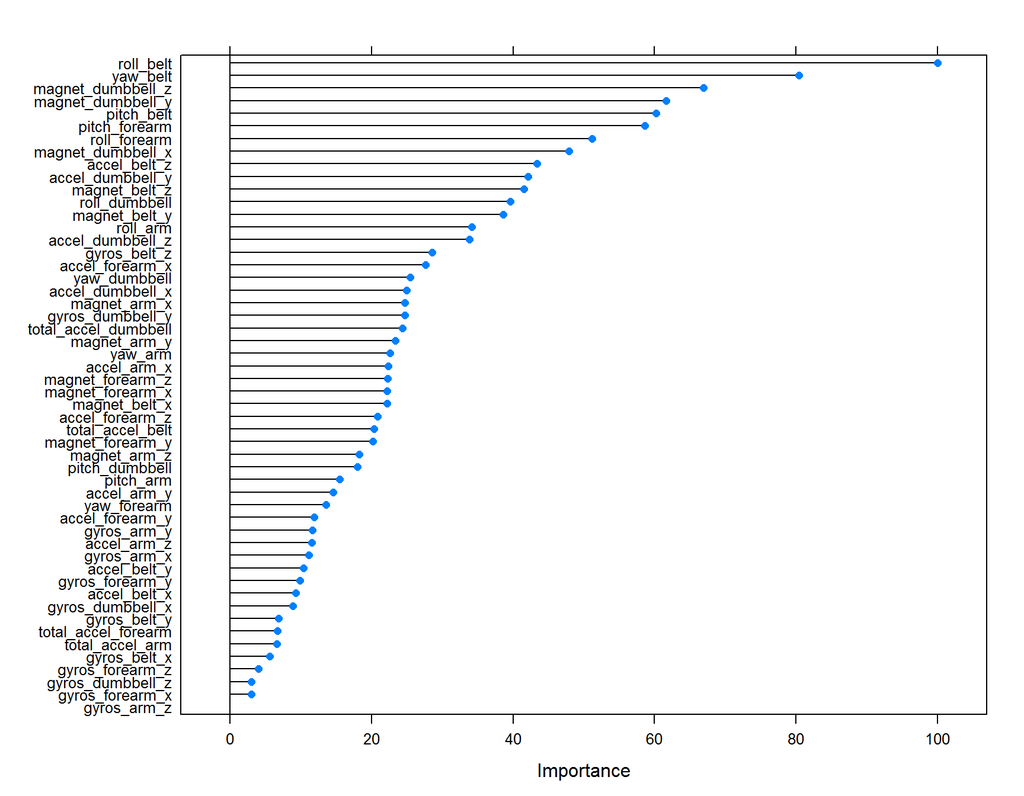

```r
plot(varImp(modelRf))
```

### Checking model accuracy with the training subset

```r
confusionMatrix(predict(modelRf, trainingTest), trainingTest$classe)
```

```
## Confusion Matrix and Statistics
##
##           Reference
## Prediction    A    B    C    D    E
##          A 2188    6    0    0    0
##          B    0 1477   19    0    0
##          C    0    4 1320   21    2
##          D    0    0    1 1236    2
##          E    0    0    0    1 1407
##
## Overall Statistics
##
##                Accuracy : 0.9927
##                  95% CI : (0.9905, 0.9945)
##     No Information Rate : 0.2847
##     P-Value [Acc > NIR] : < 2.2e-16
##
##                   Kappa : 0.9908
##  Mcnemar's Test P-Value : NA
##
## Statistics by Class:
##
##                      Class: A Class: B Class: C Class: D Class: E
## Sensitivity            1.0000   0.9933   0.9851   0.9825   0.9972
## Specificity            0.9989   0.9969   0.9957   0.9995   0.9998
## Pos Pred Value         0.9973   0.9873   0.9800   0.9976   0.9993
## Neg Pred Value         1.0000   0.9984   0.9968   0.9966   0.9994
## Prevalence             0.2847   0.1935   0.1744   0.1637   0.1836
## Detection Rate         0.2847   0.1922   0.1718   0.1609   0.1831
## Detection Prevalence   0.2855   0.1947   0.1753   0.1612   0.1832
## Balanced Accuracy      0.9995   0.9951   0.9904   0.9910   0.9985
```

Accuracy is near to 100% and the confusion matrix seems to be almost excellent.

### Predicting test data using the new model

```r
answers <- predict(modelRf, newdata = testing)
answers
```

```
##  [1] B A B A A E D B A A B C B A E E A B B B
## Levels: A B C D E
```

### Conclusion

Random Forest model was a good choice for predicting Weight Lifting Exercise types.